# Introducción a la Estadística

Lina Buitrago PhD(c), labuitragor@unal.edu.co

Juan Sosa PhD, jcsosam@unal.edu.co

# 1 ¿Qué es estadística?

La **estadística** es la ciencia que se ocupa de los métodos y las técnicas para analizar conjuntos de datos, así como de realizar inferencias a partir de ellos, con el fin de tomar decisiones racionales en situaciones que impliquen incerteza.

La **incertidumbre** es un estado de información incompleta.

La **probabilidad** es la rama de las matemáticas dedicada a la cuantificación de la incertidumbre.

# 2 Clasificación de la estadística

La **estadística descriptiva** describe y representa un grupo de datos utilizando métodos numéricos y gráficos que resumen la información contenida en ellos.

La **estadística inferencial** a partir de un conjunto de datos menor (muestra) permite efectuar estimaciones, predicciones u otras generalizaciones sobre un conjunto de datos mayor (población), apoyándose en el cálculo de probabilidades.

# 3 Algunos términos importantes

**Población**, **colectivo**, o **universo**: conjunto de todos los individuos o mediciones que satisfacen las características propias del estudio.

- **Población finita**: el número de elementos que la conforma es finito.
- **Población infinita**: el número de elementos que la forma es infinito (o es tan grande que se puede considerar como infinito).

**Muestra**: subconjunto de individuos o mediciones de una población.

- **Muestra no probabilística**: la selección de los elementos de la muestra se realiza de forma subjetiva.
- **Muestra probabilística**: todos los elementos de la población tienen una posibilidad de hacer parte de la muestra.

**Estadístico** es una función definida sobre los valores de una característica medible de una muestra.

**Parámetro** es una función definida sobre los valores de una característica medible de una población.

**Ejemplo**

- **Estadístico**: promedio muestral,
  $$\bar{x} =\frac{1}{n} \sum_{i=1}^{n} x_i$$
- **Parámetro**: promedio poblacional (población finita),
  $$\mu =\frac{1}{N} \sum_{i=1}^{N} x_i$$

# 4 Variables

Una **variable** es una característica observable o medible de un individuo, que se expresa acorde con una **escala de medición** bien definida.

- **Variables cualitativas**: se expresan en forma verbal como categorías o atributos.
- **Variables cuantitativas**: varían en términos de cantidad y se expresan en forma numérica (discretas o continuas).
- **Discretas**: existe una cantidad finita o infinita numerable de valores de la variable entre dos posibles valores cualesquiera de la misma.
- **Continuas**: existe una cantidad infinita no numerable de valores de la variable entre dos posibles valores cualesquiera de la misma.

**Ejemplo**

- El género, la raza, la afiliación política, la nacionalidad y la profesión son ejemplos de variables cualitativas.
- La edad, el peso, la estatura, la temperatura y el salario son ejemplos de variables cuantitativas.
- El número de hijos de una persona es una variable cuantitativa discreta.
- El salario en millones de pesos es una variable cuantitativa continua.

Una **matriz de datos** es una forma estructurada de organizar datos. Cada fila corresponde a un individuo y cada columna a una variable.

# 5 Medición

La **medición** es un proceso mediante el cual se asignan valores cuantitativos o cualitativos a los atributos de los elementos objeto de estudio, de acuerdo con unas reglas claramente preestablecidas.

Una **escala de medición** es un esquema específico para asignar símbolos o números con el objeto de designar los valores de una variable.

- **Escala nominal**: se clasifican los individuos respecto a las categorías del atributo. Ejemplo: tipo de material.
- **Escala ordinal**: se clasifican los individuos en una posición en relación con los niveles del atributo, pero sin precisar la distancia que hay entre las posiciones. Ejemplo: clasificación del pH como ácido, neutro y básico.
- **Escala de intervalo**: la diferencia entre dos niveles del atributo representa una distancia real que se mantiene para intervalos semejantes. No posee un cero absoluto. Ejemplo: temperatura.
- **Escala de razón**: el valor del cero es absoluto. Ejemplo: peso.

Es fundamental establecer claramente en qué escala de medición se tiene cada una de las variables objeto de estudio, ya que de esto depende el tipo de análisis que se debe llevar a cabo.

# 6 Etapas

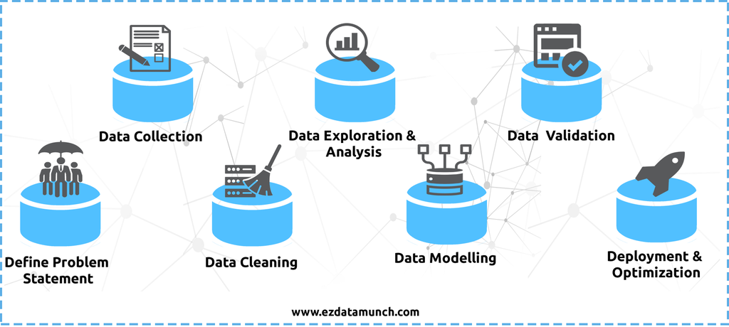

# 7 Referencias

[figure not shown]

[figure not shown]

[figure not shown]

[figure not shown]